# Resignation

Yph Lelkes

2023-30-01

1. We are interested in examining a concept we are calling “democratic resignation.” The Trump-years and the 2022 election brought about a lot of doom and gloom about democracy in America. We were interested in identifying which people were resigned, the correlates of resignation, and then experiments which increase or decrease resignation and look at the effects on various outcomes.
2. Our measure of resignation included two Agree/Disagree Questions:
- Do you agree or disagree with the following: America is heading toward the end of democracy, where free and fair elections will no longer occur.
- Do you agree or disagree with the following: Very little can be done to stop American democracy from ending in the next decade.
3. Someone is considered resigned if they agree or strongly agree to both items. Correlation between items is r=.30
4. We found a number of interesting correlates.
5. Our experiment did not work.
6. We’d like to try new treatments.
7. But also, is this interesting?

## Descriptive Results

Summary: While lots of people are worried about the future of democracy, few think its end is inevitable (roughly 17 percent of the population).

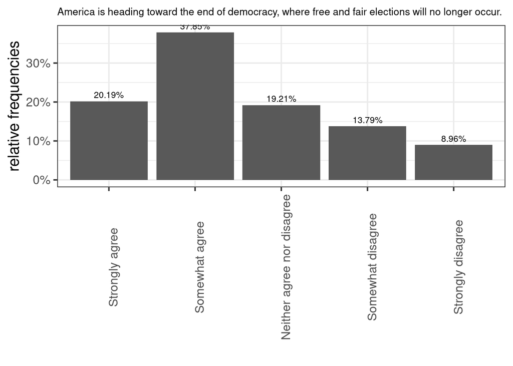

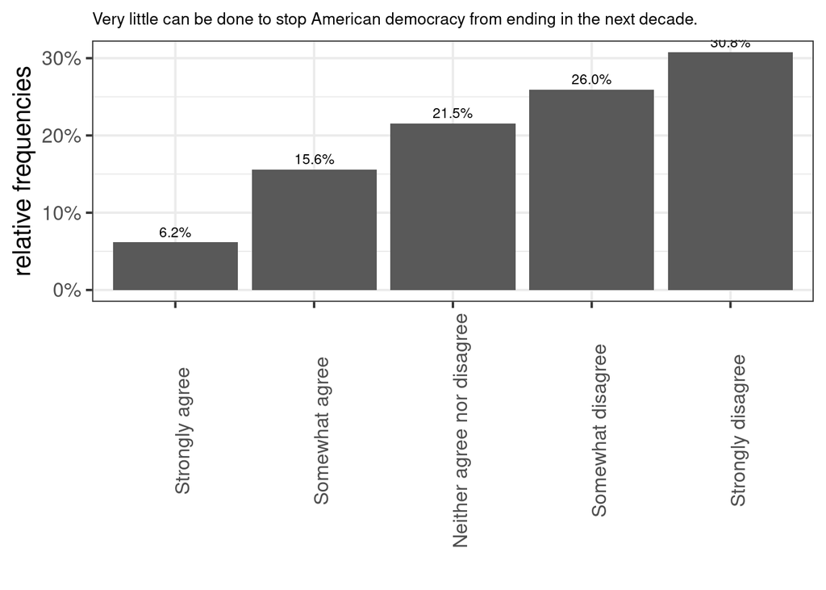

## Resignation: Agreeing with both comments (roughly 17 percent of the population)

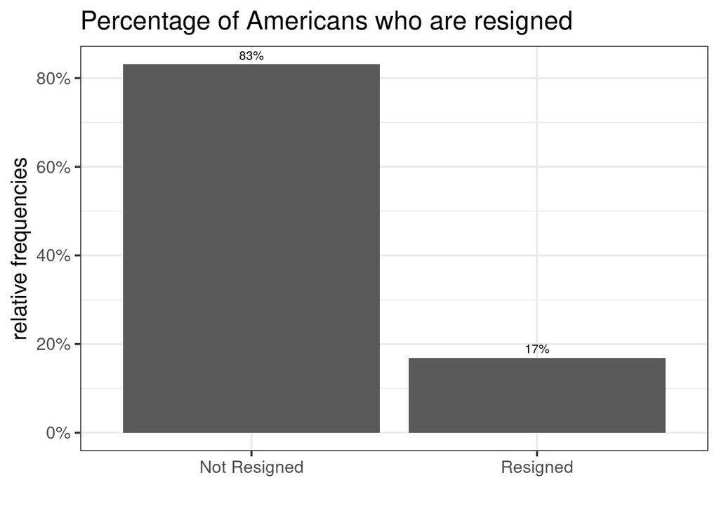

## Who is resigned?

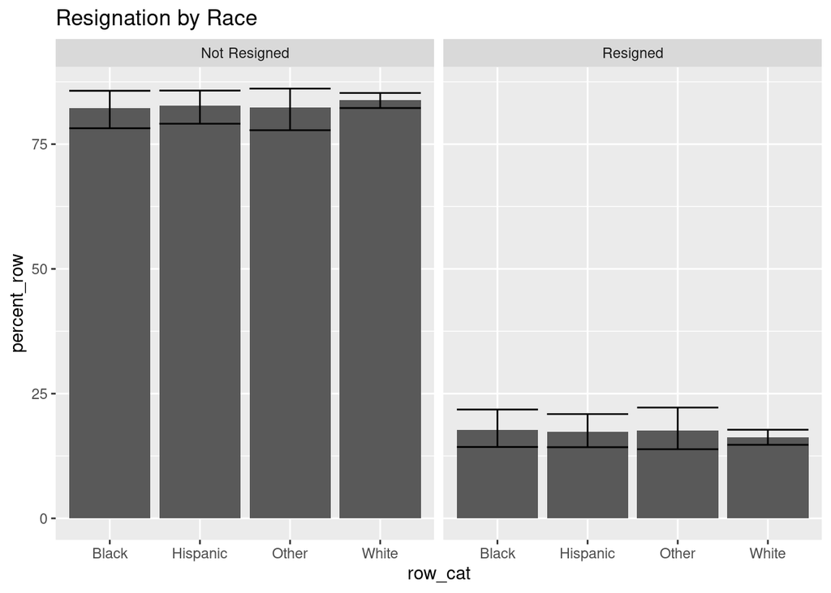

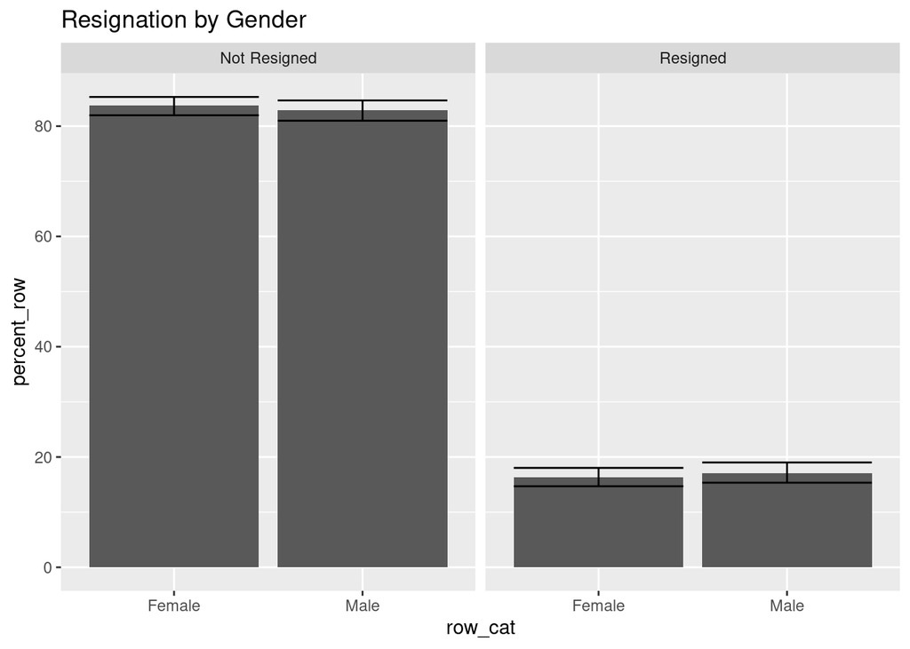

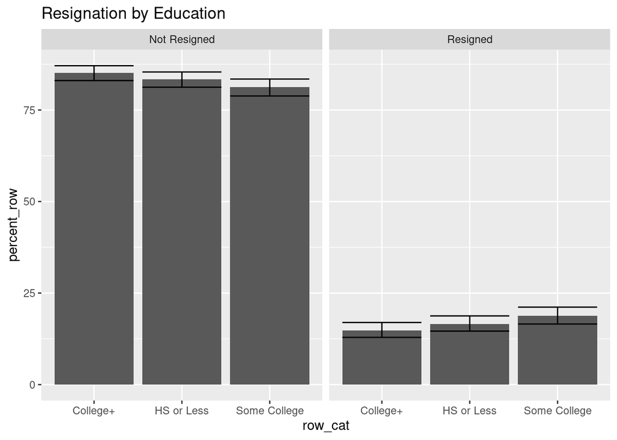

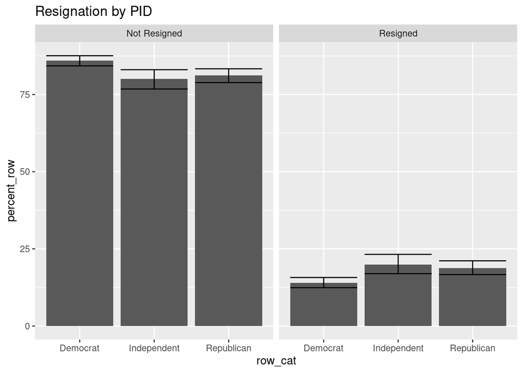

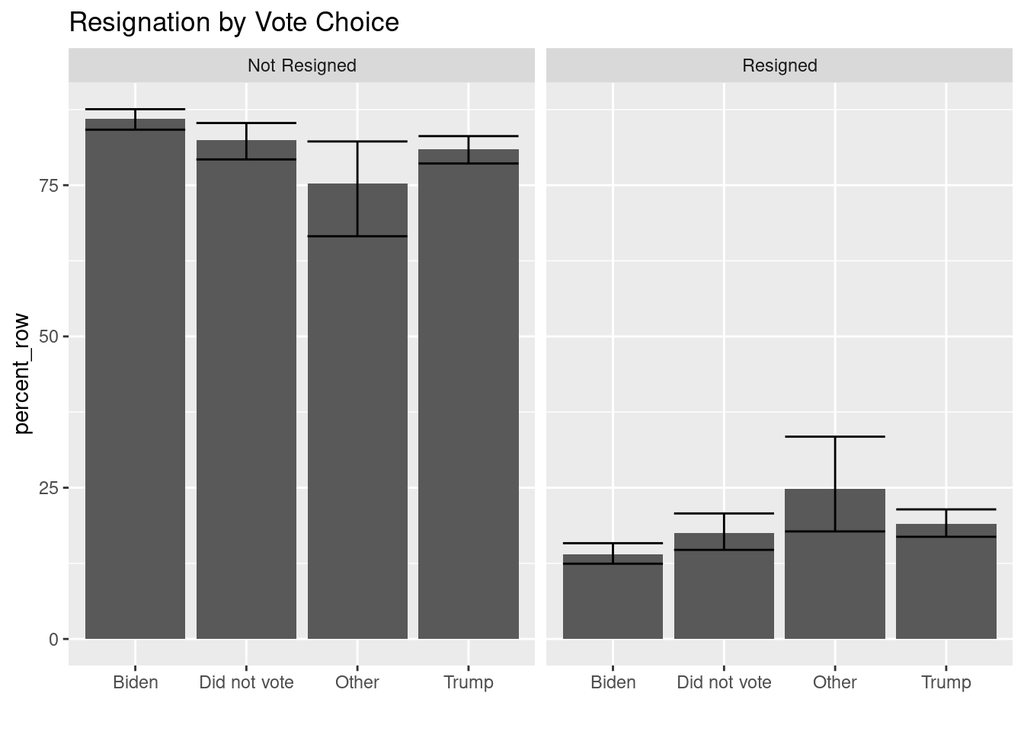

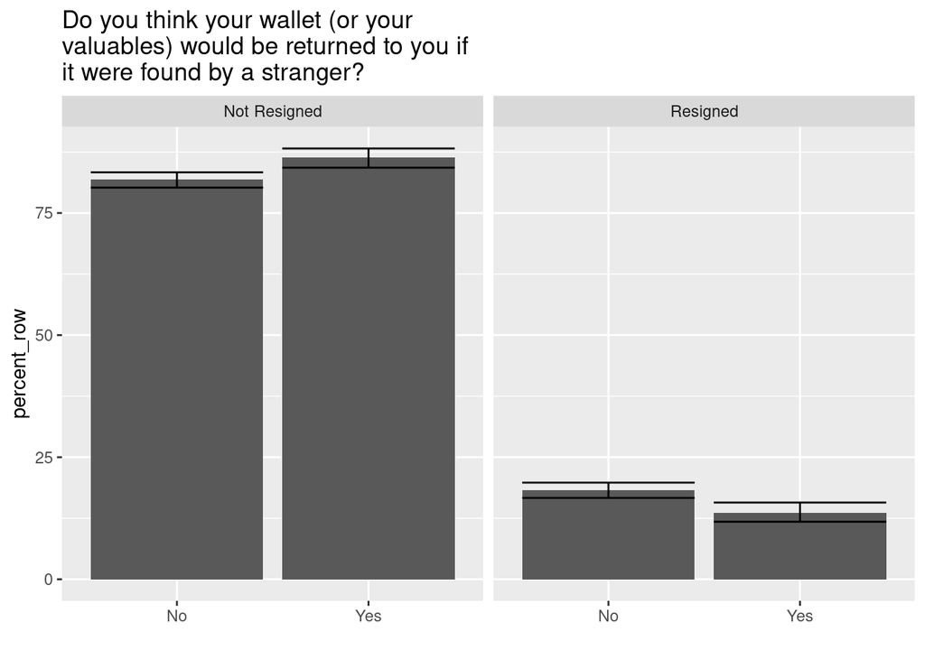

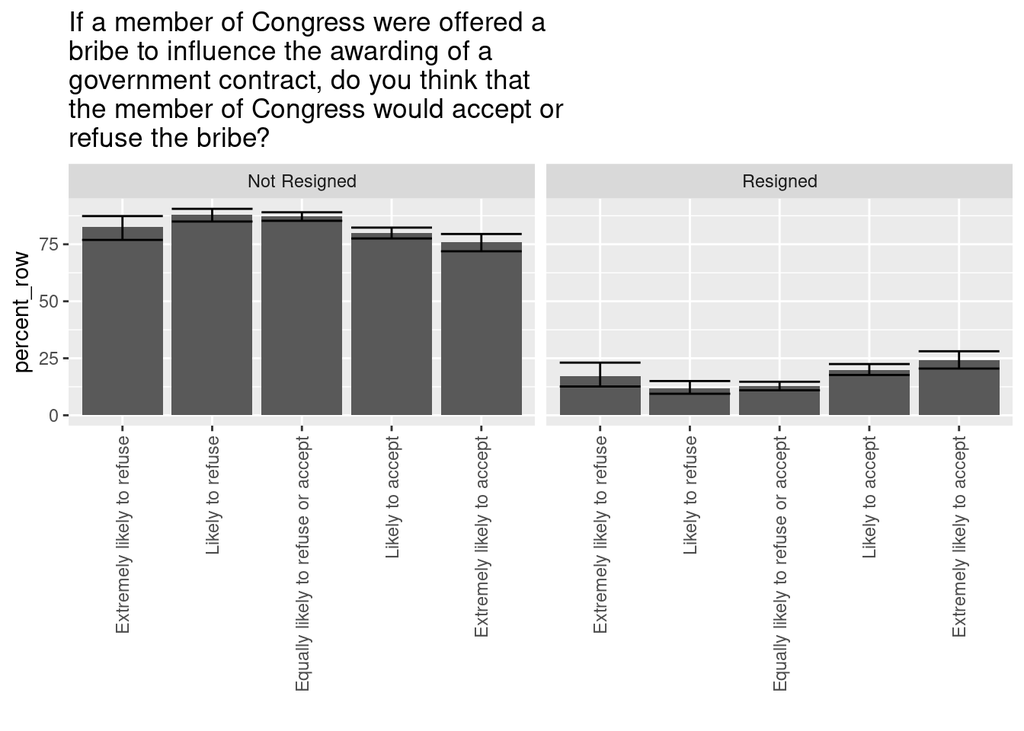

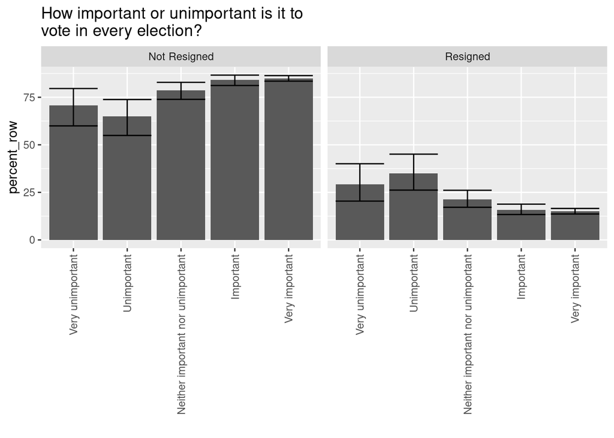

## Percent resigned by pride in being American

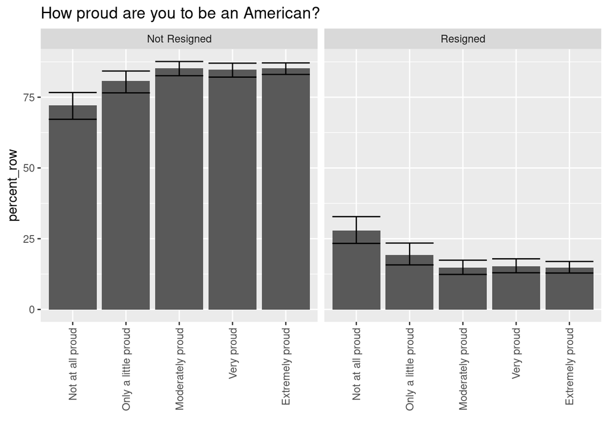

## Do you agree or disagree that you can expect fair treatment from government authorities?

[figure not shown]

### Resigned people are far more likely to support undemocratic behavior

```
## # A tibble: 10 × 4
## # Groups:   short_label [5]
##    short_label                                          resigned         m     n
##    <chr>                                                <chr>        <dbl> <int>
##  1 Democratic Norms: Censor Media                       Not Resign… 0.113   1632
##  2 Democratic Norms: Censor Media                       Resigned    0.147    300
##  3 Democratic Norms: Loyalty to Party Over Constitution Not Resign… 0.0838  1683
##  4 Democratic Norms: Loyalty to Party Over Constitution Resigned    0.145    338
##  5 Democratic Norms: Support Ignore the Judiciary       Not Resign… 0.0690  1724
##  6 Democratic Norms: Support Ignore the Judiciary       Resigned    0.158    317
##  7 Democratic Norms: Support Reduce Polling Places      Not Resign… 0.0388  1728
##  8 Democratic Norms: Support Reduce Polling Places      Resigned    0.113    345
##  9 Democratic Norms: Unilateral Executive Action        Not Resign… 0.248   1592
## 10 Democratic Norms: Unilateral Executive Action        Resigned    0.361    288
```

## Percent resigned by support for violence

```
## # A tibble: 10 × 4
## # Groups:   short_label [5]
##    short_label                                      resigned           m     n
##    <chr>                                            <chr>          <dbl> <int>
##  1 Violence: Support for Arson                      Not Resigned 0.0106   2930
##  2 Violence: Support for Arson                      Resigned     0.0478    586
##  3 Violence: Support for Assault                    Not Resigned 0.0157   2930
##  4 Violence: Support for Assault                    Resigned     0.0597    586
##  5 Violence: Support for Assault with Deadly Weapon Not Resigned 0.00785  2930
##  6 Violence: Support for Assault with Deadly Weapon Resigned     0.0410    586
##  7 Violence: Support for Murder                     Not Resigned 0.00683  2930
##  8 Violence: Support for Murder                     Resigned     0.0358    586
##  9 Violence: Support for Vandalism                  Not Resigned 0.0532   2930
## 10 Violence: Support for Vandalism                  Resigned     0.130     586
```

## The experiment

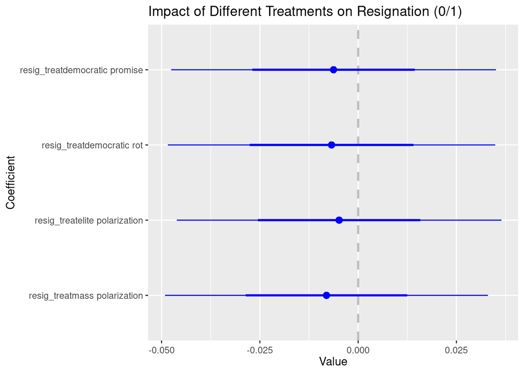

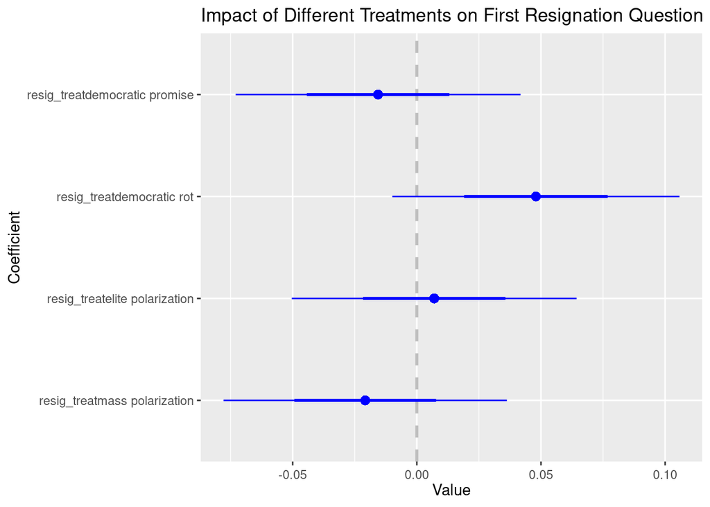

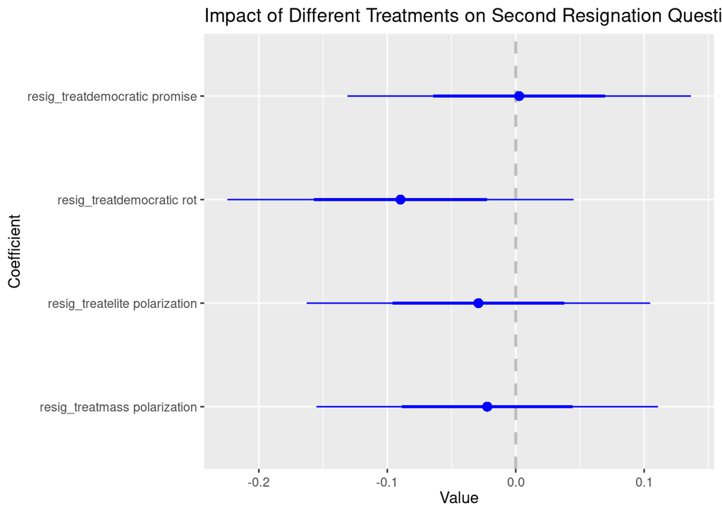

## New experiment

We’ve culled and edited excerpts from two sets of op-eds from various political scientists: 1. https://www.usatoday.com/story/opinion/contributors/2022/07/03/americans-divided-civil-war-unlikely/7767742001/?gnt-cfr=1 2. https://www.theguardian.com/us-news/2022/nov/06/how-close-is-the-us-to-civil-war-barbara-f-walter-stephen-march-christopher-parker

### Civil war is inevitable - USA Today

If you take civil conflict from recent history, you find a chillingly familiar list of initial conditions: politics hardening along identity lines; a surge of armed groups; an erosion of institutions. Ethnic polarization and democratic backsliding are especially persistent predictors of state collapse.

In 2015, democracy raters like the Polity Project gave the United States a perfect score of 10 – one it had enjoyed for decades. Then Donald Trump was elected president, and America’s score fell to 8.

In 2019, after the failed impeachment of Trump, Polity’s score fell further to 7. Finally, on Jan. 7, 2021, immediately following the insurrection, Polity announced a drop to a 5, meaning “no longer a democracy.”

Rapid plunges to this level are persistently correlated with outbreaks of civil war. If you trace back from a civil war you find polarized politics, or a surge of protest and arms.

### Civil war is very unlikely - USA Today (1)

As a general rule, enemies prefer to loathe one another in peace. That’s because war – especially civil war – is disastrous. It kills people, destroys economies and weakens the country to outside enemies. This gives all sides huge incentives to avoid violence.

Because of these costs, most political factions don’t fight. An extremist militia in the United States would be no exception. Few things are harder than launching an insurgency against a powerful state. Intelligence services will hunt you down. Justice systems will jail you. You will live clandestinely, full of hardships. This is why even the most disaffected groups are often dissuaded from violence.

### Civil war is very unlikely - USA Today (2)

If you take civil conflict from recent history, you find a chillingly familiar list of initial conditions: politics hardening along identity lines; a surge of armed groups; an erosion of institutions. But apply this to the United States with care. The data driving these results comes from predicting massive acts of violence – genocide or revolutionary wars – almost all from low- and middle-income countries. It’s dubious to use these models to predict a different phenomenon – low-scale insurgency – in America or other rich, advanced democracies.

The fact is, even societies with hardened identities rarely erupt in conflict. One study looked at every ethnic pairing in Africa and Eastern Europe in the late 20th century and found no more than 1 in 1,000 turned violent in a given year.

### Civil war is inevitable - The Guardian (1)

Civil war experts know that two factors put countries at high risk of civil war. The US has one of these risk factors and remains dangerously close to the second. Neither risk factor has diminished since 6 January. The first is ethnic factionalism. This happens when citizens in a country organise themselves into political parties based on ethnic, religious, or racial identity rather than ideology. The second is anocracy. This is when a government is neither fully democratic nor fully autocratic; it’s something in between. Civil wars almost never happen in full, healthy, strong democracies. They also seldom happen in full autocracies. Violence almost always breaks out in countries in the middle – those with weak and unstable pseudo-democracies.

### Civil war is inevitable - The Guardian (2)

The groups that tend to resort to violence are not the poorest groups, or the most downtrodden. It’s the group that had once been politically dominant but is losing power. It’s the loss of political status – a sense of resentment that they are being replaced and that the identity of their country is no longer theirs – that tends to motivate these groups to organise. Today, the Republican party and its base of white, Christian voters are losing their dominant position in American politics and society as a result of demographic changes. Whites are the slowest-growing demographic in the US and will no longer be a majority of the population by around 2044. Their status will continue to decline as America becomes more multi-ethnic, multiracial, and multireligious, and the result will be increasing resentment and fear at what lies ahead.

America’s democracy declined rapidly between 2016 and 2020. Since 6 January 2021, the US has failed to strengthen its democracy in any way, leaving it vulnerable to continued backsliding into the middle zone. And America’s two big political parties remain deeply divided by race and religion. If these underlying conditions do not change, a leader like Stewart Rhodes of the Oath Keepers can go to jail, but other disaffected white men will take his place.

### Civil war is inevitable - The Guardian (3)

The United States is a textbook example of a country headed towards civil war. The trends increasingly point one way, and while nobody knows the future, little – if anything – is being done, by anyone, to try to prevent the collapse of the republic. Belief in democracy is ebbing. The legitimacy of institutions is declining. America increasingly is entering a state where its citizens don’t want to belong to the same country. These are conditions ripe for political violence.

No civil war ever has a single cause. It’s always a multitude of factors that lead to decline and collapse. The current US has several of what the CIA calls “threat multipliers”: environmental crises continue to batter the country, economic inequality is at its highest level since the founding of the country, and demographic change means that the US will be a minority white country within just over two decades. All of these factors tend to contribute to civil unrest wherever they are found in the world.

### Civil war is inevitable - The Guardian (4)

Election-related violence generally takes place when the following four factors are present: a highly competitive election that can shift power; partisan division based on identity; winner-takes-all two-party election systems in which political identities are polarised; and an unwillingness to punish violence on the part of the dominant group. All four are present in America now, and will be more amplified in 2024.

We’re almost there. White angst over increasing racial diversity makes another Trump candidacy (and presidency) likely, pushing us into anocracy. Democrats are having none of that. They’ll resist going down the slippery slope to autocracy the same way that their 19th-century counterparts, the party of Lincoln, refused to let the Confederacy bust up the union. Likewise, should Democrats prevail in 2024, Republicans will revolt – the 6 January Capitol attack is a forewarning.

Either way, I’ll wager that a civil war featuring terrorism, guerrilla war and ethnic cleansing will be waged from sea to shining sea. In the end, race and racism will lead to another very American conflagration.

### Civil war is very unlikely - The Guardian

The US is not yet in a civil war. According to a 2012 declassified report by the CIA on insurgencies, a country is experiencing an open insurgency when sustained violence by increasingly active extremists has become the norm.

Insurgency experts wondered whether 6 January would be the beginning of such a sustained series of attacks. This has not yet happened, in part because of aggressive counter-measures by the FBI. The FBI has arrested more than 700 individuals who participated in the riot, charging 225 of them with assaulting, resisting or impeding officers or employees. Stewart Rhodes, the leader of the Oath Keepers, will almost certainly go to jail for his role in helping to organise the insurrection, as will numerous other participants.

### Placebo

In Monterey Bay, the sea otter lives in kelp forest and estuary habitats.

The sea otter is an important part of both of these habitats — It’s a keystone species, which means that the health of sea otters is a good indication of the health of other species and ecosystems nearby.

In the kelp forest, it eats sea urchins and other animals that graze on giant kelp. When urchins go unchecked, they create areas called “urchin barrens” where nothing else lives. With sea otters helping to keep the urchins under control, kelp forests can thrive and support a rich community of plants and animals.